# Debugging fitsir problems

Daniel Park and Ben Bolker

21:44 09 July 2016

## Optim problem

```r
library("deSolve")
library("bbmle")
library(lattice) ## for splom()
library(numDeriv)
## source("../R/fitSIR_funs.R")
## load *development* version of the package ...
library("devtools")
load_all("..")
## library("fitsir")
## set up names for consistency with fitsir
bombay2 <- setNames(bombay,c("tvec","count"))

#(fitP <- coef(fitsir(bombay2, start = startfun())))

#findSens(bombay2, fitP, plot.it = TRUE)
```

First, here is a set of parameters we get from the initial curve fittting attempt with : this is using `incidence=FALSE` and the new sensitivity machinery, but *not* using the new “autostart” machinery (i.e. using the not-necessarily-sensible default values of $\beta=0.12$, $\gamma=0.09$, $N=10^4$, $I(0)=0.01$), or

```r
summarize.pars(p0 <- startfun())
```

```
##           R0            r       infper           i0           I0
##     1.333333     0.030000    11.111111     0.010000   100.000000
##            N
## 10000.000000
```

```r
p1 <- p0
p1$log.beta <- p1$log.beta + 0.1
p2 <- p0
p2$log.beta <- p2$log.beta + 0.2
p3 <- p0
p3$log.beta <- p2$log.beta + 0.3
pList <- list(p0,p1,p2,p3)
```

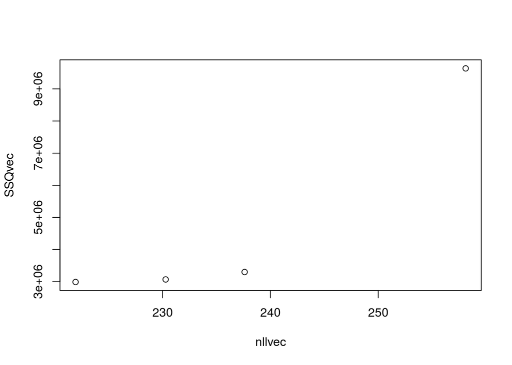

```r
## TO DO: get rid of attach()/detach() in findSens ...
SSQvec <- sapply(pList,findSens,data=bombay2,incidence=FALSE)["SSQ",]
tmpfun <- function(p) with(bombay2,SIR.logLik()(p,count,tvec))
nllvec <- sapply(pList,tmpfun)
plot(nllvec,SSQvec)
```

Hmmm. I thought SSQ and negative log-likelihood should be perfectly linearly related, because `dnorm2` is defined as

$$\begin{split}
\hat\sigma & = \sqrt{\sum{(x_i-\mu_i)^2/(n-1)}} \\
\cal L & = -n/2 \log(2 \pi) -n \log(\hat \sigma) - \sum((x_i-\mu_i)^2)/(2 \hat \sigma^2)
\end{split}$$

Maybe they’re not, but they should have their minima in the same place … ??

The first time we iterate it, we get a large jump, but if we iterate the process few more times, we get a stable answer.

```r
## set up matrix for results
nsteps <- 8
npar <- 4
f0 <- unlist(startfun())
sfits <- matrix(NA,ncol=npar,nrow=nsteps,
               dimnames=list(NULL,names(f0)))
sfits[1,] <- f0  ## set first row
ffits <- sfits   ## setup for next step (see below)
for (i in 2:nsteps) {
  sfits[i,] <- fitsir.optim(bombay2, start=sfits[i-1,])
}
```

Now let’s try the same thing with plain old `fitsir` (`dnorm2` instead of SSQ, Nelder-Mead instead of BFGS + sensitivity equations)

```r
for (i in 2:nsteps) {
  ffits[i,] <- coef(fitsir(bombay2, start=ffits[i-1,]))
}
```

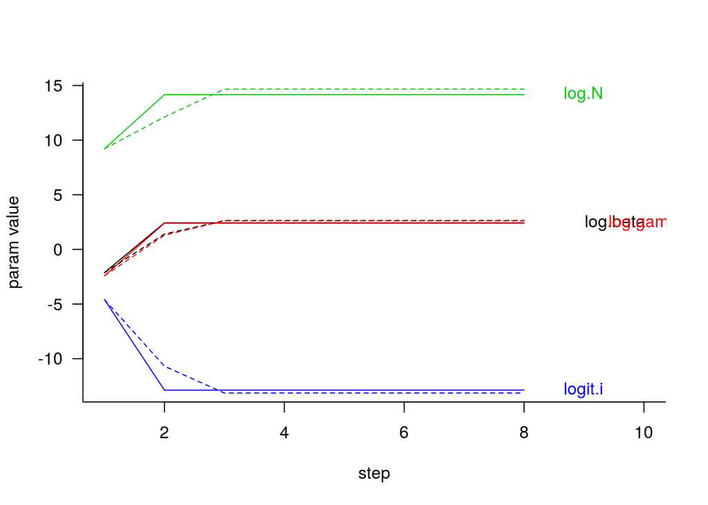

How different are the fits, and the implied likelihoods?

```r
ffit.final <- ffits[nsteps,]
sfit.final <- sfits[nsteps,]
tmpfun(ffit.final)
```

```
## [1] 169.0718
```

```r
tmpfun(sfit.final)
```

```
## [1] 248.1471
```

If we start with the `sfits` result do we get back to the `ffits` result (and *vice versa*) ?

```r
## start fitsir from fitsir.optim best-fit
newfit <- fitsir(bombay2, start=sfit.final)
## start fitsir.optim from fitsir best-fit
newfit2 <- fitsir.optim(bombay2, start=ffit.final)
reldiff <- function(x,y) {
    max(abs((x-y)/((x+y)/2)))
}
print(cmat <- matrix(
    c(reldiff(sfit.final,coef(newfit)),
      reldiff(ffit.final,coef(newfit)),
      reldiff(sfit.final,newfit2),
      reldiff(ffit.final,newfit2)),
    nrow=2,
    dimnames=list(orig=c("fitsir","fitsir.optim"),
                  restart=c("fitsir.optim","fitsir"))),
    digits=3)
```

```
##               restart
## orig           fitsir.optim fitsir
##   fitsir            0.00868 0.0799
##   fitsir.optim      0.09552 0.0097
```

i.e., both methods get stuck when we start them at the alternative location. Visualizing a “slice” along a line in parameter space (where 0 represents the place where the old fitsir gets stuck, 1 represents the solution found by `fitsir.optim`):

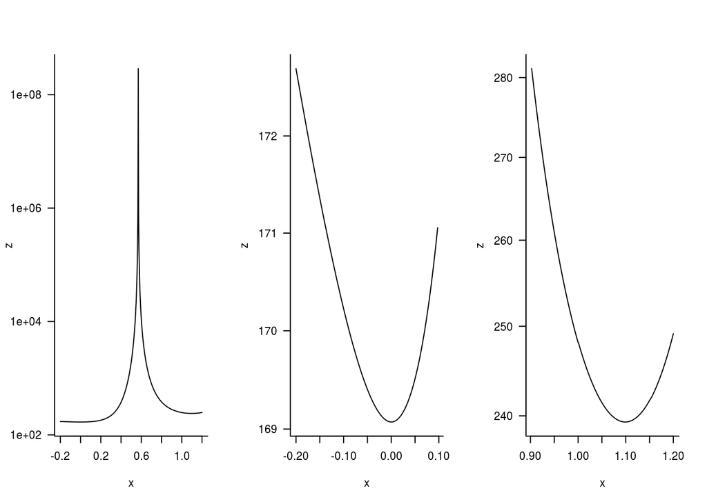

```r
slice1 <- bbmle:::slicetrans(ffit.final,sfit.final,
                   tmpfun,
                   extend=0.2)
par(las=1,bty="l")
par(mfrow=c(1,3))
with(slice1$slices[[1]],
     plot(x,z,log="y",type="l"))
with(subset(slice1$slices[[1]],x<0.1),
     plot(x,z,log="y",type="l"))
with(subset(slice1$slices[[1]],x>0.9),
     plot(x,z,log="y",type="l"))
```

```r
## redo 'slice transect' computation
params <- ffit.final; params2 <- sfit.final
extend <- c(0.2,0.2); nt <- 401
cutoff <- 500
np <- length(params)
slicep <- sort(unique(c(0, 1, seq(-extend[1], 1 + extend[2],
                                  length = nt))))
slicepars <- t(sapply(slicep, function(x) (1 - x) * params +
                                          x * params2))
## select either end of the transect
s2Apars1 <- slicepars[slicep>(-0.2) & slicep<0.1,]
s2Apars2 <- slicepars[slicep>1 & slicep<1.2,]
## get first and last rows ...
s2Arange1 <- t(s2Apars1[c(1,nrow(s2Apars1)),])
s2Arange2 <- t(s2Apars2[c(1,nrow(s2Apars2)),])
s2A <- slice2D(sfit.final,
        tmpfun,
        tranges=s2Arange1,
        nt=41,verbose=FALSE)
## clean up crazy values: should incorporate in slice2D ...
s2Ax <- s2A
for (i in 1:3) {
    for (j in 1:4) {
        if (!is.null(s2Ax$slices[[i]][[j]])) {
            zz <- s2Ax$slices[[i]][[j]]$z
            s2Ax$slices[[i]][[j]]$z[zz>cutoff] <- NA
        }
    }
}
```

```r
library(rgl)
persp3d(1:41,1:41,matrix(s2Ax$slices[[1]][[2]]$z,41),
        col="blue",alpha=0.8,zlab="NLL")
```

OK, I’m giving up on trying to visualize the local region for now.

Trying to compute local derivatives/Hessians isn’t making sense either … ?

```r
grad(tmpfun,sfit.final,method="simple",method.args=list(eps=1e-2))
grad(tmpfun,ffit.final,method="simple",method.args=list(eps=1e-3))
h1 <- hessian(tmpfun,ffit.final)
h2 <- hessian(tmpfun,sfit.final)
```

How different are the trajectories?

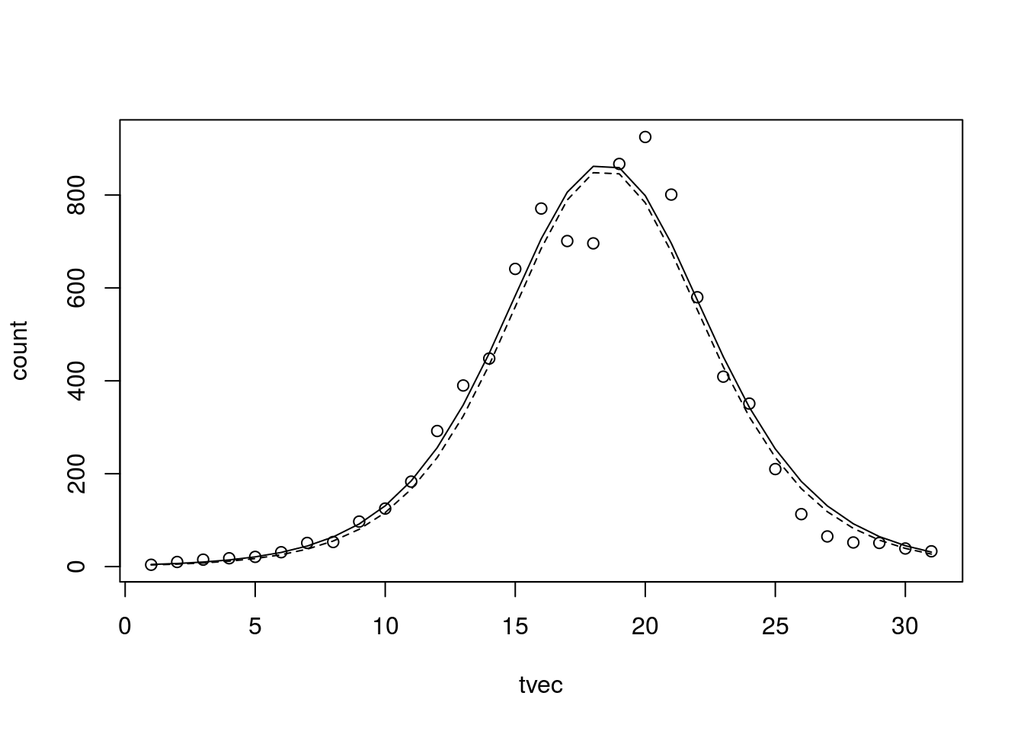

```r
straj <- SIR.detsim(bombay2$tvec,trans.pars(sfit.final))
ftraj <- SIR.detsim(bombay2$tvec,trans.pars(ffit.final))
with(bombay2,plot(tvec,count))
lines(straj)
lines(ftraj,lty=2)
```

How different are the parameter values from a more epidemiological point of view (i.e. in terms of $R_0$, $r$, etc.)?

```r
print(summarize.pars(ffit.final),digits=3)
```

```
##       R0        r   infper       i0       I0        N
## 1.04e+00 3.92e-01 9.11e-02 2.57e-06 3.64e+00 1.42e+06
```

```r
print(summarize.pars(sfit.final),digits=3)
```

```
##       R0        r   infper       i0       I0        N
## 1.03e+00 3.79e-01 7.33e-02 1.98e-06 4.64e+00 2.35e+06
```

Maybe the problem is caused by using the “wrong” parameterization? Would we better off parameterizing via `log(R0)`, `log(r)` … rather than `log(beta)`, `log(gamma)`, … ??

Do we do better (can we ignore this problem) if we use autostart … ?

(following is broken ATM)

```r
autofit.f <- fitsir(bombay2, start=startfun(auto=TRUE,data=bombay2))
## start fitsir.optim from fitsir best-fit
autofit.s <- fitsir.optim(bombay2, start=ffit.final)
```

## Startfun problem

We have the following four equations:

$$\begin{aligned}
r &= \beta - \gamma \\
\frac{Q_p}{I_p} &= \frac{\beta \gamma}{N} \\
I(0) &= N i_0\\
\frac{\gamma N}{\beta} &= N - I(0) - \sum_0^{\tau_\text{peak}} I(t) dt
\end{aligned}$$

Here is a made-up data:

```r
pars <- list(
    beta = 0.5,
    gamma = 0.1,
    N = 500,
    i0 = 0.01
)
tvec <- bombay2$tvec
r = SIR.detsim(tvec, pars, reportAll = TRUE)
count = r$I
S = r$S
incid = c(NA,-diff(S))
data = data.frame(tvec, count)
```

I’m going to test the equations one by one…
$$r = \beta - \gamma$$

```r
attach(pars)
ncrit <- Inf
it <- 1
spar <- 0.5
while (ncrit>1 && it<10) {
    ss <- smooth.spline(tvec,log(count),spar=spar)
    dd <- predict(ss,deriv=1)$y
    ncrit <- sum(diff(sign(dd))!=0)
    spar <- (1+spar)/2
}
if (it==10) stop("couldn't smooth enough")
        ## find max value
ss.tmax <- uniroot(function(x) predict(ss,x,deriv=1)$y,range(tvec))$root
        ## find a point halfway between initial and max
        ##  scaling could be adjustable?
ss.thalf <- min(tvec)+0.5*(ss.tmax-min(tvec))

m1 <- lm(log(count)~tvec,data=subset(data,tvec<ss.thalf))
(r <- as.numeric(coef(m1)[2])) ##beta - gamma
```

```
## [1] 0.3715749
```

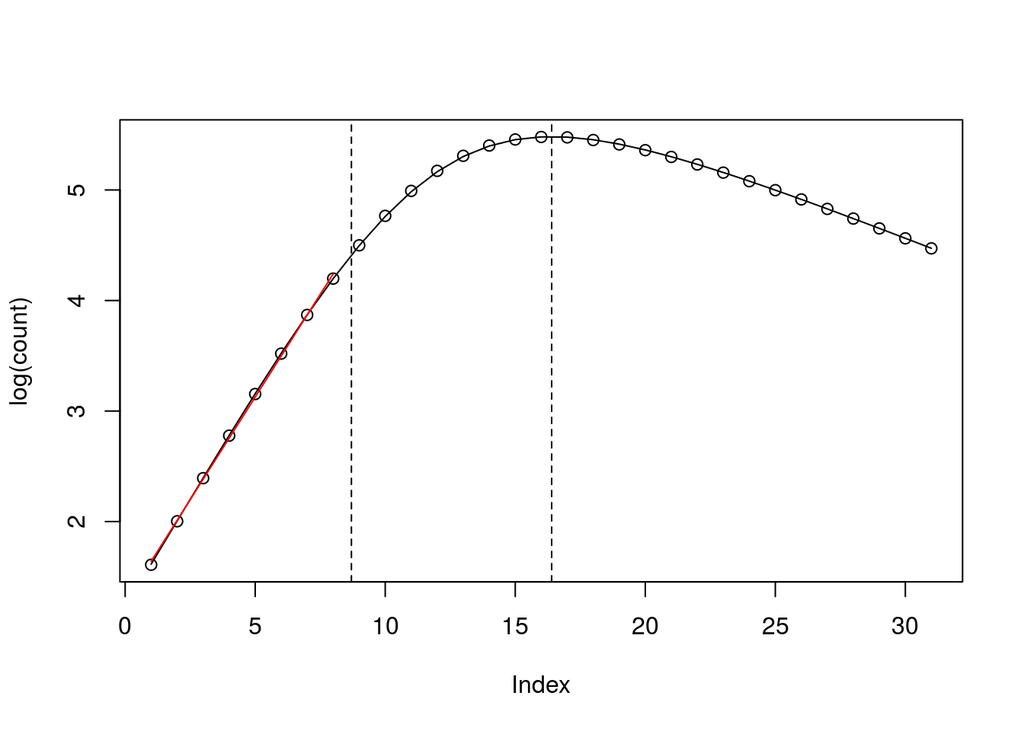

```r
plot(log(count))
lines(predict(ss))
abline(v = ss.tmax, lty = 2)
abline(v = ss.thalf, lty = 2)
lines(predict(m1), col = 2)
```

0.37 is fairly close to 0.4 so this one is OK.

$$Q_p = -\frac{\beta \gamma I_p}{N}$$

```r
iniI <- count[1] ## N * i0
## curvature of spline at max: could also do this, possibly
##  more robustly, from a local quadratic fit
Qp.real = -beta*gamma*max(count)/N
Qp.alt <- predict(ss,ss.tmax,deriv=2)$y
(Q <- c(Qp.real=Qp.real, Qp.alt=Qp.alt))
```

```
##     Qp.real      Qp.alt
## -0.02397224 -0.02456237
```

This is OK too. For convenience, we’re going to let $\alpha = \frac{\beta \gamma}{N} = -\frac{Q_p}{I_p}$. This is nice because we can approximate the right term. Here is the problem:

$$\frac{\gamma N}{\beta} = \hat{S} = N - I(0) - \sum_0^{\tau_\text{peak}} I(t) dt$,$$

where $I(t)$ is incidence

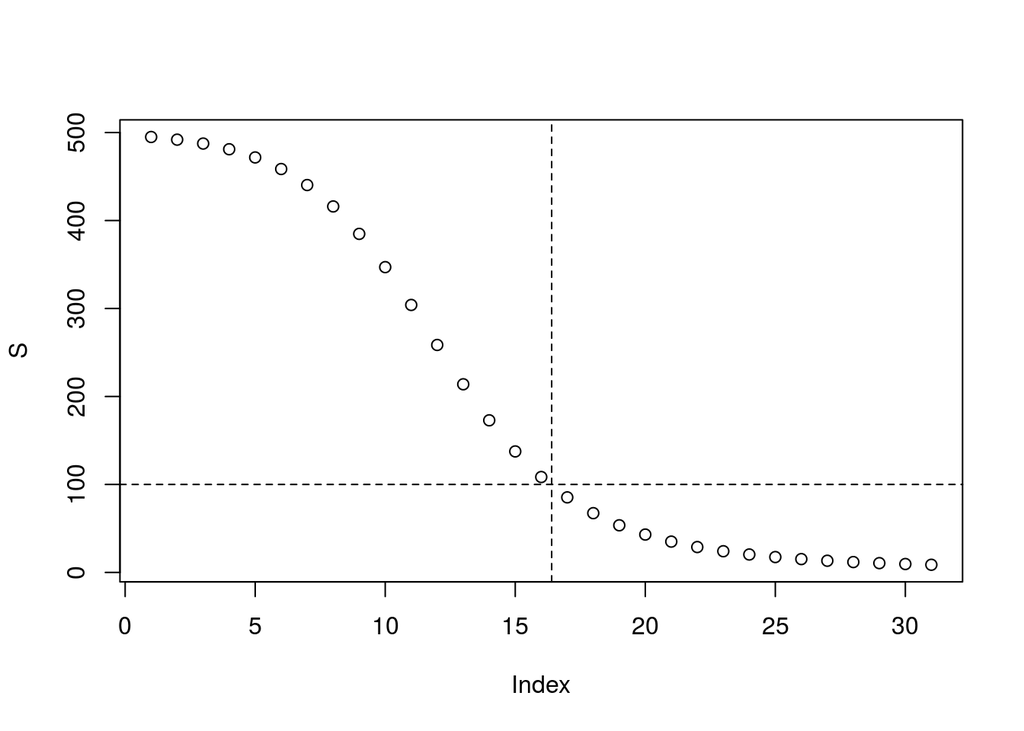

```r
plot(S)
abline(v = ss.tmax, lty = 2)
abline(h = gamma * N/beta, lty = 2)
```

The problem is that we can’t approximate incidence from prevalence so well using this formula: $P = I/\gamma$

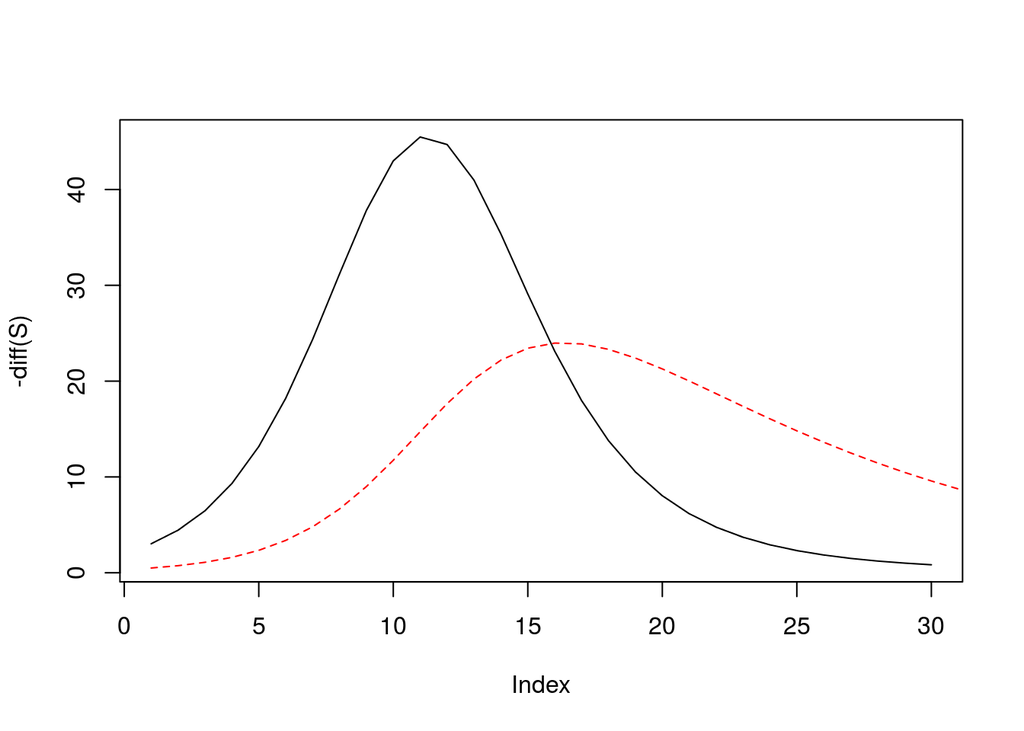

```r
plot(-diff(S), type = "l")
lines(count*gamma,lty=2,col=2)
```

This is a problem because this is what we want to do:

$$\begin{aligned}
\frac{\gamma N}{\beta} &= N - I(0) - \sum_0^{\tau_\text{peak}} I(t) dt\\
\frac{\gamma N}{\beta} &= N - I(0) - \gamma \sum_0^{\tau_\text{peak}} P(t) dt\\
N(1 - \frac{\gamma}{\beta}) &= I(0) + \gamma \sum_0^{\tau_\text{peak}} P(t) dt\\
\frac{\beta\gamma}{\alpha} (1 - \frac{\gamma}{\beta}) &= I(0) + \gamma \sum_0^{\tau_\text{peak}} P(t) dt\\
\gamma \frac{r}{\alpha} &= I(0) + \gamma \sum_0^{\tau_\text{peak}} P(t) dt\\
\gamma (\frac{r}{\alpha} - \sum_0^{\tau_\text{peak}} P(t) dt) &= I(0) \\
\gamma &= I(0)/(\frac{r}{\alpha} - \sum_0^{\tau_\text{peak}} P(t) dt)\\
\end{aligned}$$

We test it with the predicted values

```r
Ip = max(exp(predict(ss)$y))

alpha = -Qp.alt/Ip

(new.gamma = iniI/(r/alpha - sum(count[1:ss.tmax])))
```

```
## [1] 0.002513872
```

Here’s is the real gamma value:

```r
iniI/(0.4/(-Qp.real/max(count)) - (N - 100 -iniI)/gamma)
```

```
## [1] 0.1
```

In the equations above, we’re assuming that $N - I_0 - \sum (P(t) \gamma) = \hat{S}$ but it doesn’t work so well…

```r
detach(pars)
```

Can we get anything from knowing the peak prevalence ($I_p$) other than the calculation we’ve already done with $Q_p$? The $dI/dt$ equation isn’t useful (it just gives us $\beta S = \gamma$, and we don’t know $S$ without doing the fancy stuff we’re working for …

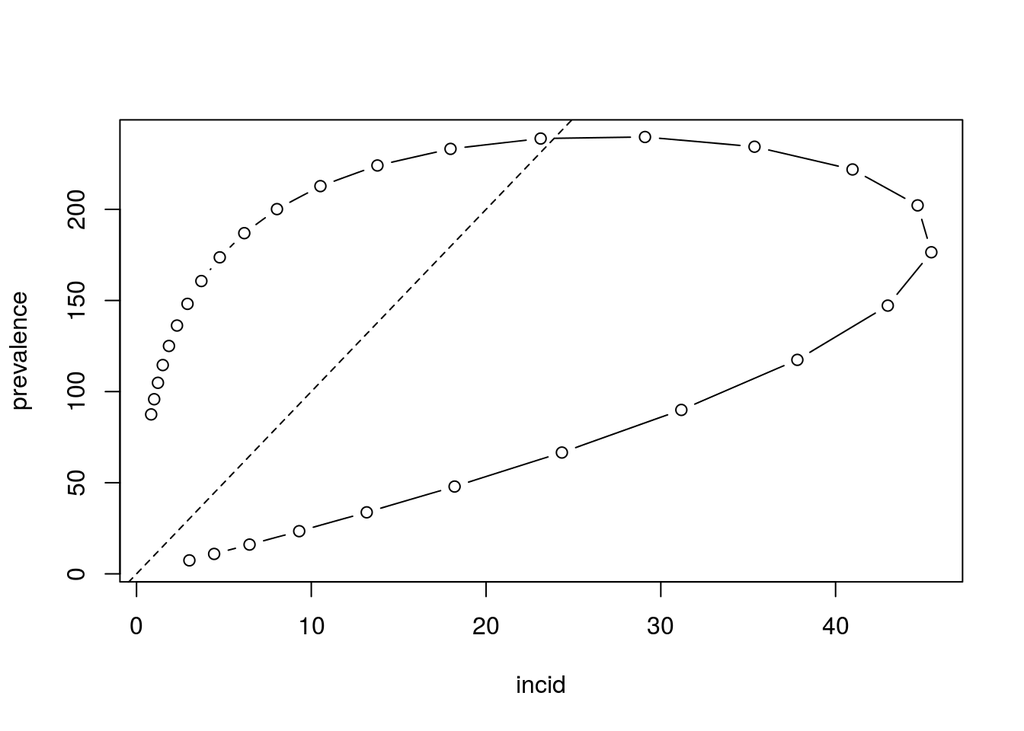

```r
plot(incid,count,type="b",
     ylab="prevalence")
abline(a=0,b=1/gamma,lty=2)
```